# Group Project 1

Biology 368/664 Bucknell University

Ian Mawn, Kaitlin McLain, and Emily Scholfield

21 Feb 2022

# R for Dummies (BIOL208 Edition)

Welcome to this R tutorial for BIOL208! This is designed for someone who is brand new to R, so we are going to start with the very basics. To make this interesting, we’ll be looking at a dataset on irises since plants are extremely important to the study of ecology and evolution. To best follow along, you should have a new markdown file open in R studio where you can copy and paste line sof code from thsi tutrotial for you to practice running on your own.

Typically, when doing data analysis in R, we want to begin by loading in the data and packages that we will use.

### Loading Libraries and Data

R has many built in functions that will allow us to perform all kinds of actions. However, sometimes it is useful to load some additional functions that other R users have created. We do this by loading in libraries. In the code chunk below (the grey box; this is where code is typed and run) you can see that I have loaded in some libraries.

```r
# Load other packages here.
#I just put in any libraries we might need. Don't know if we actually need them, or need more.
if (!require("tidyverse")) install.packages("tidyverse"); library(tidyverse)
if (!require("cowplot")) install.packages("cowplot"); library(cowplot)
if (!require("UsingR")) install.packages("UsingR"); library(UsingR)
if (!require("ggpubr")) install.packages("ggpubr"); library(ggpubr)
```

```r
if (!require("readxl")) install.packages("readxl"); library(readxl)
```

#### Libraries:

For some examples, one library is called tidyverse. It contains a ton of useful tools, but the one most relevant to this tutorial is called **ggplot**. **ggplot** allows us to create all kinds of plots to visualize our data, which you will learn more about below. You can also see the library called **cowplot**. **cowplot** is useful as it allows us to easily change the aesthetics of our graphs, and keep the designs consistent between different graphs. Finally, you can see the library **readxl**. This is useful for exactly what it sounds like… reading Microsoft Excel files! This bring us to the next step, entering data into R.

#### Data:

In the code chunk below I am going to read in some data regarding features of different species of iris (the flower). There are a few main parts of the code to think about when loading in data. First, the **read_csv()** function tells R to load in a comma separated values (csv) file with the name of the file in the parentheses. Here, you can see that our data is called “iris.csv”. It is very important to type the file name exactly as it is saved on your computer, otherwise R will not be able to find it. Once the data is loaded in, we need to call it something. That is what the “IrisData <-” part of the code means. In English, it translates to: IrisData is the data found in the csv file “iris.csv”. When you read in a data file, you will see it appear in your “Environment” on the right of R studio. If you click on “IrisData” in your Environment, a new tab will appear with all of the data.

```r
IrisData <- read_csv ("iris.csv")
```

What happens if your data is in an excel file instead of a csv file? Fear not! Data can also be loaded in from an excel file using the **read_excel()** function instead of **read_csv()**. In a normal data analysis, you would only read in the data once using *either* the **read_csv()** *or* **read_excel()** functions. Your data will only read in properly if the file type matches the function you’re using, so pay attention to how your data is saved before you read it in!

### Using R (The Basics)

Now that we have the pieces we need, we can start learning about R. You have already seen a few aspects of R in the last section, but here we will go into some more detail about the basic functions of R to get you started with analyzing data.

This document is an R markdown file. The highlights of a markdown file is that you can have mostly regular text (not code) but still include code and their output in specific sections. This is especially useful as it allows for lots of explanation of what the code does, like we need to do here for a tutorial. Markdowns are also convenient because they can be converted to many different formats such as a PDF (like you’re reading), an html, and others.

As mentioned before, the grey sections are called code chunks. This is where the actual code is written and ran. You can insert a code chunk to your markdown file by clicking the green box with “<sup>+</sup>C” at the top of R studio. When you do this, a drop-down menu appears where you can choose a coding language (since this is about R, we will only use that). Refer to the image below if you can’t find the code chunk button.

[figure not shown]

Adding a New Code Chunk

```r
#Example code chunk
4+1
```

```
[1] 5
```

```r
#This line will not run
```

Code within chunks can be run in a few ways:  
1. In the top right of a chunk is a green play button that will run every line of code in the chunk.  
2. Placing your cursor on a line you want to run, or highlight it, and hit command + enter (or control + enter).  
3. Click the run button in the top of the screen, which will bring up a few options for running code. You can run all of the code chunks in your document at once (in order from top to bottom) with this option. This is useful for ensuring your code is functional when finalizing a document.

[figure not shown]

Running Code

Looking at the example code chunk above, there a few points to make about coding in R. First, you can see a green line that starts with a “#”. The hashtag/number/pound symbol tells R that this line is a comment, and that it should not be run as code. If you run the code chunk you will see that that line is skipped, and the only output comes from the addition found in the next line (the output should be 5 since 4+1=5). Comments are very useful for explaining your code as you write it. This is helpful for yourself in the future, so you can remind yourself how different code works, and for other people reading through or referencing your code.

Another useful bit of information is how to assign values to objects. Essentially, this is a way of naming things. You have actually already seen this in action, where we assigned our iris data to the object IrisData using the assign operator **<-**. Lets go to the next code chunk to see an example and notice how all of these values/variables will get stored in the Environment.

```r
#Essentially, the <- means "store this value under this name," so you can think of the symbol as the word "is" or "equals."
this <- "that"

#In the line above we are storing the word that under the name this. So the code would read in English "this is that". And if we print out the object (a.k.a. run the code) "this," it will output the word "that." Try this out yourself! In your markdown file, try running the next line, but be sure to run the line above first.
this
```

```
[1] "that"
```

```r
#Other examples
n <- 5
z <- 10
n+z
```

```
[1] 15
```

```r
z/n
```

```
[1] 2
```

```r
(z+n)/3 -> five
five * 10
```

```
[1] 50
```

This is especially useful for storing data under a specific name, like we did at the beginning with the iris data. If you run the line of code below, it will print out all of the iris data.

```r
IrisData
```

| sepal.length | sepal.width | petal.length | petal.width | variety |
| --- | --- | --- | --- | --- |
| 5.1 | 3.5 | 1.4 | 0.2 | Setosa |
| 4.9 | 3.0 | 1.4 | 0.2 | Setosa |
| 4.7 | 3.2 | 1.3 | 0.2 | Setosa |
| 4.6 | 3.1 | 1.5 | 0.2 | Setosa |
| 5.0 | 3.6 | 1.4 | 0.2 | Setosa |
| 5.4 | 3.9 | 1.7 | 0.4 | Setosa |
| 4.6 | 3.4 | 1.4 | 0.3 | Setosa |
| 5.0 | 3.4 | 1.5 | 0.2 | Setosa |
| 4.4 | 2.9 | 1.4 | 0.2 | Setosa |
| 4.9 | 3.1 | 1.5 | 0.1 | Setosa |

[output cut: 140 more lines]

We can also access specific variables within the data using the **$** symbol. So if we only wanted to see the data about petal length, we can run the following code:

```r
IrisData$petal.length
```

```
  [1] 1.4 1.4 1.3 1.5 1.4 1.7 1.4 1.5 1.4 1.5 1.5 1.6 1.4 1.1 1.2 1.5 1.3 1.4 1.7 1.5 1.7 1.5 1.0 1.7 1.9 1.6 1.6
 [28] 1.5 1.4 1.6 1.6 1.5 1.5 1.4 1.5 1.2 1.3 1.4 1.3 1.5 1.3 1.3 1.3 1.6 1.9 1.4 1.6 1.4 1.5 1.4 4.7 4.5 4.9 4.0
 [55] 4.6 4.5 4.7 3.3 4.6 3.9 3.5 4.2 4.0 4.7 3.6 4.4 4.5 4.1 4.5 3.9 4.8 4.0 4.9 4.7 4.3 4.4 4.8 5.0 4.5 3.5 3.8
 [82] 3.7 3.9 5.1 4.5 4.5 4.7 4.4 4.1 4.0 4.4 4.6 4.0 3.3 4.2 4.2 4.2 4.3 3.0 4.1 6.0 5.1 5.9 5.6 5.8 6.6 4.5 6.3
[109] 5.8 6.1 5.1 5.3 5.5 5.0 5.1 5.3 5.5 6.7 6.9 5.0 5.7 4.9 6.7 4.9 5.7 6.0 4.8 4.9 5.6 5.8 6.1 6.4 5.6 5.1 5.6
[136] 6.1 5.6 5.5 4.8 5.4 5.6 5.1 5.1 5.9 5.7 5.2 5.0 5.2 5.4 5.1
```

Those are the basic functions you should know about R moving forward. Now we can explore more tools you can use to explore and analyze a set of data.

### Exploring Your Data

Once we have our data, it is important to explore it before beginning analysis. First, you want to come up with the question that you will attempt to answer *before analyzing your data*. This is important since we want to remain objective throughout the data analysis process.

For this tutorial, we’re interested in the following questions:  
1. Are sepal and petal dimensions correlated within a single species?  
2. Do sepal and petal dimensions differ between Iris species?

One way to begin to understand your dataset is to run the **str()** (structure) function. This outputs lots of information about the dataset. It will show you each column of the data, the class of the column (what type of data it is: a number (num), a word (or character: chr), etc), the number of observations in the column, and some of the data within each column. This is useful for ensuring that each column contains the data you expect. For example, one column in the dataset is sepal length, so I would expect to find in the output of str() that there is a column called sepal length (it is actually called sepal.length, but that is good), it should be a number, there should be 150 observations, and the data should actually be numbers.

In the chunk below I will run str() on the iris dataset to confirm my expectations and make sure that the data looks right.

```r
str(IrisData)
```

```
spec_tbl_df [150 × 5] (S3: spec_tbl_df/tbl_df/tbl/data.frame)
 $ sepal.length: num [1:150] 5.1 4.9 4.7 4.6 5 5.4 4.6 5 4.4 4.9 ...
 $ sepal.width : num [1:150] 3.5 3 3.2 3.1 3.6 3.9 3.4 3.4 2.9 3.1 ...
 $ petal.length: num [1:150] 1.4 1.4 1.3 1.5 1.4 1.7 1.4 1.5 1.4 1.5 ...
 $ petal.width : num [1:150] 0.2 0.2 0.2 0.2 0.2 0.4 0.3 0.2 0.2 0.1 ...
 $ variety     : chr [1:150] "Setosa" "Setosa" "Setosa" "Setosa" ...
 - attr(*, "spec")=
  .. cols(
  ..   sepal.length = col_double(),
  ..   sepal.width = col_double(),
  ..   petal.length = col_double(),
  ..   petal.width = col_double(),
  ..   variety = col_character()
  .. )
 - attr(*, "problems")=<externalptr>
```

One thing that stands out to me after running **str()** is the “variety” column. For starters, you may want to rename the column to something that’s easier for you to understand, such as “species.” You can do this using the **rename()** function as explained below. Once you’ve run that code, you can click on the dataset in your Environment and should see the column has been renamed.

```r
#The rename() function allows this format: DataName <- rename(DataName, NewVariableName = OldVariableName)
IrisData <- rename(IrisData, species = variety)
```

If we want to compare variables between species of irises, this column will be very useful. To make those comparisons easier, I am going to tell R that this variable is categorical. We can group the data into those categories using the as.factor() function below.

```r
IrisData$species <- as.factor(IrisData$species)
#This code tells R to replace the current character species column of IrisData with the new factor species column.

str(IrisData)
```

```
spec_tbl_df [150 × 5] (S3: spec_tbl_df/tbl_df/tbl/data.frame)
 $ sepal.length: num [1:150] 5.1 4.9 4.7 4.6 5 5.4 4.6 5 4.4 4.9 ...
 $ sepal.width : num [1:150] 3.5 3 3.2 3.1 3.6 3.9 3.4 3.4 2.9 3.1 ...
 $ petal.length: num [1:150] 1.4 1.4 1.3 1.5 1.4 1.7 1.4 1.5 1.4 1.5 ...
 $ petal.width : num [1:150] 0.2 0.2 0.2 0.2 0.2 0.4 0.3 0.2 0.2 0.1 ...
 $ species     : Factor w/ 3 levels "Setosa","Versicolor",..: 1 1 1 1 1 1 1 1 1 1 ...
 - attr(*, "spec")=
  .. cols(
  ..   sepal.length = col_double(),
  ..   sepal.width = col_double(),
  ..   petal.length = col_double(),
  ..   petal.width = col_double(),
  ..   variety = col_character()
  .. )
 - attr(*, "problems")=<externalptr>
```

```r
#Running str() again shows that species is now a factor with 3 levels which correspond to the 3 different species.
```

It can also be useful to look at the top and bottom of your dataset using the **head()** and **tail()** functions, which show the first 6 rows and last 6 rows respectively. This is useful to ensure that the data makes sense (the data is numeric if you were expecting that) and to make sure that the correct number of rows are present (for example, make sure that the last few rows are not empty). Or, if the data is time dependent, you can use these functions to make sure that the first times are in the first row and the last times are at the end.

```r
#This chunk will output two functions, and it will separate them into two windows if you run the whole chunk. Here, the left window is the head function, and the right window is the tail function. The output windows will always proceed left to right to correspond with your code from top to bottom.
head(IrisData)
```

| sepal.length | sepal.width | petal.length | petal.width | species |
| --- | --- | --- | --- | --- |
| 5.1 | 3.5 | 1.4 | 0.2 | Setosa |
| 4.9 | 3.0 | 1.4 | 0.2 | Setosa |
| 4.7 | 3.2 | 1.3 | 0.2 | Setosa |
| 4.6 | 3.1 | 1.5 | 0.2 | Setosa |
| 5.0 | 3.6 | 1.4 | 0.2 | Setosa |
| 5.4 | 3.9 | 1.7 | 0.4 | Setosa |

```r
tail(IrisData)
```

| sepal.length | sepal.width | petal.length | petal.width | species |
| --- | --- | --- | --- | --- |
| 6.7 | 3.3 | 5.7 | 2.5 | Virginica |
| 6.7 | 3.0 | 5.2 | 2.3 | Virginica |
| 6.3 | 2.5 | 5.0 | 1.9 | Virginica |
| 6.5 | 3.0 | 5.2 | 2.0 | Virginica |
| 6.2 | 3.4 | 5.4 | 2.3 | Virginica |
| 5.9 | 3.0 | 5.1 | 1.8 | Virginica |

A very useful function for data exploration is **summary()**. This outputs the mean, median, min, max, and first and third quartiles of any numeric data, and the number of observations within our variables. This is an important step in any data exploration. This can be useful for validating your data against external sources. If external sources show that the average sepal length of irises is 100 cm long, but our sepal lengths range from 4.3 to 7.9 cm, something might be wrong. Luckily the average is closer to 5-7 cm, so our data does make sense.

```r
summary(IrisData)
```

```
  sepal.length    sepal.width     petal.length    petal.width          species
 Min.   :4.300   Min.   :2.000   Min.   :1.000   Min.   :0.100   Setosa    :50
 1st Qu.:5.100   1st Qu.:2.800   1st Qu.:1.600   1st Qu.:0.300   Versicolor:50
 Median :5.800   Median :3.000   Median :4.350   Median :1.300   Virginica :50
 Mean   :5.843   Mean   :3.057   Mean   :3.758   Mean   :1.199
 3rd Qu.:6.400   3rd Qu.:3.300   3rd Qu.:5.100   3rd Qu.:1.800
 Max.   :7.900   Max.   :4.400   Max.   :6.900   Max.   :2.500
```

### Visualization with Graphs

Now that we’ve spent a substantial amount of time exploring and organizing our data, we’re ready to start analyzing it! The first step here is to visualize our data since up until this point, all we’ve been looking at are numbers (which can be hard for identifying relationships and patterns between variables). When considering what graphs would be best for visualizing our data, we should consider our questions of interest and what types of variables we’re dealing with. As a reminder, our two questions of interest are below:  
1. Are sepal and petal dimensions correlated within a single species?  
2. Do sepal and petal dimensions differ between Iris species?

#### Are sepal and petal dimensions correlated within a single species?

Let’s focus on question number one first. There are a couple different, more specific questions we can look at within this. Such as, the relationship between sepal length and sepal width, or petal length and petal width. Perhaps we can even compare sepal length and petal length, or sepal width and petal width. Wow! There are a ton of different relationships to look at. For our purposes, let’s narrow in on two relationships:  
1. Sepal length and sepal width  
2. Sepal length and petal length

Since all of these variables are numerical, a scatterplot would best represent the data. The **ggplot** function is extremely useful for creating graphs. Below is the code for creating a basic scatterplot.

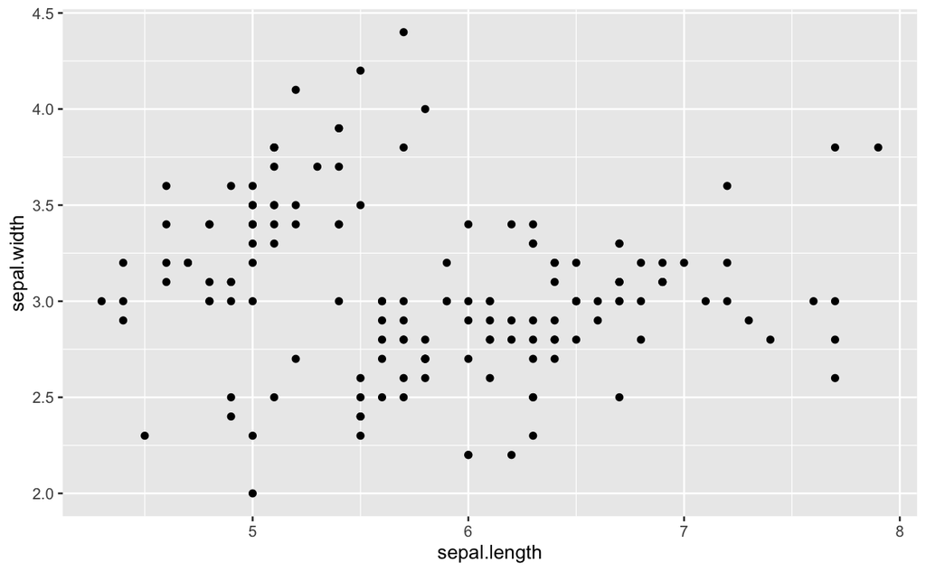

```r
#Follows the form: ggplot(DataName, aes(x=VariableOne, y=VariableTwo)) + geom_point()
ggplot(IrisData, aes(x=sepal.length, y=sepal.width)) + geom_point()
```

```r
#Learning check: Try running the code without + geom_point(). What happens?
```

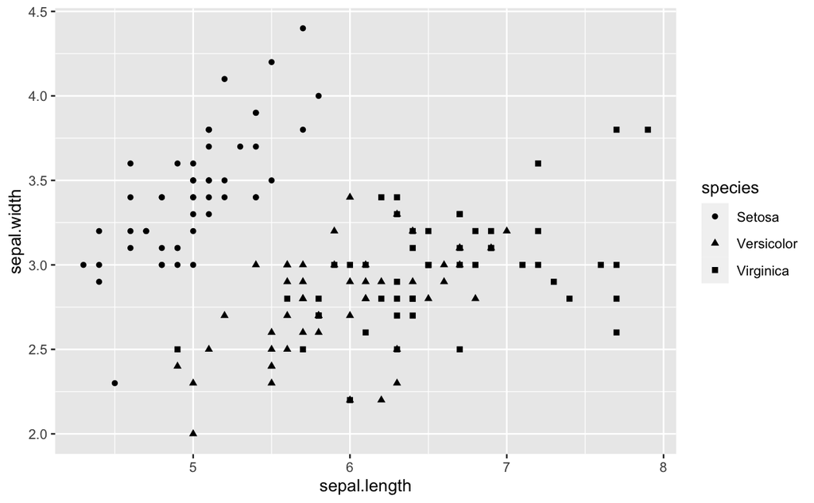

```r
ggplot(IrisData, aes(x=sepal.length, y=sepal.width, shape=species)) + geom_point()
```